# **Group Work Project 2 of Risk Management**

| Student Group | 8183 |
| --- | --- |
| Team Member A | Ebenezer Yeboah |
| Team Member B | Christson Hartono |
| Team Member C | Eric Walter Pefura-Yone |

```python
# Loading packages
try:
    import hmms
except Exception:
    !pip install hmms
    import hmms

!pip install pgmpy  # Install pgmpy if needed

# Standard imports
import numpy as np
import pandas as pd
import matplotlib.pyplot as plt
import matplotlib.dates as mdates
import matplotlib.patches as mpatches
from matplotlib.collections import LineCollection
from matplotlib.colors import Colormap, ListedColormap, BoundaryNorm
import seaborn as sns
import datetime as dt
import random

# Specific imports for probabilistic models
from pgmpy.estimators import HillClimbSearch, K2Score, BayesianEstimator
from pgmpy.models import BayesianModel
from tqdm import tqdm

# Additional imports for network visualization
import networkx as nx
import pylab as plt
```

## **Step 1: Pseudocode for Hidden Markov Model (HMM)** (Sean R. Eddy; Sean R Eddy; Rabiner and Juang)

## **a. Forward algorithm pseudocode and toy example**

## **a1. Forward algorithm pseudocode**

**Goal**: Compute $P(O \mid \lambda)$, the probability of observing $O$ given the model $\lambda = (\pi, A, B)$.

```
Input: Observation sequence O = [o₁, o₂, ..., oₜ]
       States Q = [q₁, q₂, ..., qₙ] (N possible hidden states)
       Initial probabilities π = [π₁, π₂, ..., πₙ]
       Transition matrix A = [aᵢⱼ] (size N × N)
       Emission matrix B = [bᵢ(oₜ)] (size N × M)

Output: Probability P(O | λ)

// Step 1: Initialization (t = 1)
for i = 1 to N:
    α[1, i] = πᵢ * bᵢ(o₁)
    // α(1, i) is the probability of being in state qᵢ at time t = 1

// Step 2: Recursion (t = 2 to T)
for t = 2 to T:
    for j = 1 to N:
        α[t, j] = (Σ from i = 1 to N of α[t - 1, i] * aᵢⱼ) * bⱼ(oₜ)
        // Sum over previous states qᵢ, multiply by transition aᵢⱼ and emission bⱼ(oₜ)

// Step 3: Termination
P(O | λ) = Σ from i = 1 to N of α[T, i]
// Sum over all states at final time T

return P(O | λ)
End Forward Algorithm
```

## **a2. Toy example for forward algorithm**

Our model λ is described as follow:

- For N = 2 states (example: "Rain" and "Sunshine");
- T = 2 observations (example: "Umbrella" or "Sunglasses");
- and initial probabilities π = [0.6, 0.4].

We Suppose that:

**Transition Matrix (A):**  
$ A = \begin{bmatrix} P(\text{Rain} \mid \text{Rain}) & P(\text{Sunshine} \mid \text{Rain}) \\ P(\text{Rain} \mid \text{Sunshine}) & P(\text{Sunshine} \mid \text{Sunshine}) \end{bmatrix} = \begin{bmatrix} 0.7 & 0.3 \\ 0.4 & 0.6 \end{bmatrix} $

**Emission Matrix (B):**  
$ B = \begin{bmatrix} P(\text{Umbrella} \mid \text{Rain}) & P(\text{Umbrella} \mid \text{Sunshine}) \\ P(\text{Sunglasses} \mid \text{Rain}) & P(\text{Sunglasses} \mid \text{Sunshine}) \end{bmatrix} = \begin{bmatrix} 0.9 & 0.2 \\ 0.1 & 0.8 \end{bmatrix} $

We can apply, forward algorithm as below:

**Step 1: Initialization $ (t = 1 )$** For the first observation $o_1$:  
$\alpha(1, 1) = \pi_1 \cdot b_1(o_1) = 0.6 \cdot 0.9 = \mathbf{0.54}$

$\alpha(1, 2) = \pi_2 \cdot b_2(o_1) = 0.4 \cdot 0.2 = \mathbf{0.08}$

**Step 2: Recursion $( t = 2 )$** For the second observation $o_2$ :

1. **State 1**:

$ \alpha(2, 1) = \left( \alpha(1, 1) \cdot a_{11} + \alpha(1, 2) \cdot a_{21} \right) \cdot b_1(o_2) $ $ = \left( 0.54 \cdot 0.7 + 0.08 \cdot 0.4 \right) \cdot 0.1 = (0.378 + 0.032) \cdot 0.1 = \mathbf{0.041} $

2. **State 2**:  
   $ \alpha(2, 2) = \left( \alpha(1, 1) \cdot a_{12} + \alpha(1, 2) \cdot a_{22} \right) \cdot b_2(o_2) $  
   $ = \left( 0.54 \cdot 0.3 + 0.08 \cdot 0.6 \right) \cdot 0.8 = (0.162 + 0.048) \cdot 0.8 = \mathbf{0.168} $

**Step 3: Termination** Sum the probabilities at $( t = 2 )$:  
$ P(O|\lambda) = \alpha(2, 1) + \alpha(2, 2) = 0.041 + 0.168 = \mathbf{0.209} $

**Interpretation**  
There is a 20.9% chance of observing the sequence O = [o₁, o₂] giving our model λ

## **b. Backward algorithm pseudocode and toy example**

## **b1. Backward algorithm pseudocode**

**Goal**: Compute the backward probabilities $\beta(t, i)$, which represent the likelihood of future observations given the current state.

```
Input: Observation sequence O = [o₁, o₂, ..., oₜ]
       States Q = [q₁, q₂, ..., qₙ] (N possible hidden states)
       Transition matrix A = [aᵢⱼ] (size N × N)
       Emission matrix B = [bᵢ(oₜ)] (size N × M)


Output: Probability P(O | λ)

// Step 1: Initialization (t = T)
for i = 1 to N:
    β[T, i] = 1
    // β(T, i) is the probability of the "empty" future given state qᵢ at time T

// Step 2: Recursion (t = T - 1 to 1)
for t = T - 1 down to 1:
    for i = 1 to N:
        β[t, i] = Σ from j = 1 to N of aᵢⱼ * bⱼ(oₜ₊₁) * β[t + 1, j]
        // Sum over next states qⱼ, multiply by transition aᵢⱼ, emission bⱼ(oₜ₊₁), and β[t + 1, j]

// Step 3: Termination
P(O | λ) = Σ from i = 1 to N of πᵢ * bᵢ(o₁) * β[1, i]
// Sum over all states at time t = 1, weighted by initial probability πᵢ and emission bᵢ(o₁)

return P(O | λ)
End Backward Algorithm
```

## **b2. Toy example for backward algorithm**

We used the same parameters for model λ.

**Step 1: Initialization $(t = T = 2)$**  
At the final time step ( t = 2 ), initialize backward probabilities to **1** for all states:  
$ \beta(2, 1) = 1 \quad \text{(Rain)}, \quad \beta(2, 2) = 1 \quad \text{(Sunshine)} $

**Step 2: Recursion $ (t = 1)$**  
Compute backward probabilities for $ t = 1 $ using the recursion formula:  
$ \beta(t, i) = \sum_{j=1}^2 a_{ij} \cdot b_j(o_{t+1}) \cdot \beta(t+1, j) $

1. **For state $ q_1 = \text{Rain}$:**

$ \beta(1, 1) = \left( a_{11} \cdot b_1(o_2) \cdot \beta(2, 1) \right) + \left( a_{12} \cdot b_2(o_2) \cdot \beta(2, 2) \right) $ $ = \left( 0.7 \cdot 0.1 \cdot 1 \right) + \left( 0.3 \cdot 0.8 \cdot 1 \right) = 0.07 + 0.24 = \mathbf{0.31} $

2. **For state $ q_2 = \text{Sunshine} $:**

$ \beta(1, 2) = \left( a_{21} \cdot b_1(o_2) \cdot \beta(2, 1) \right) + \left( a_{22} \cdot b_2(o_2) \cdot \beta(2, 2) \right) $ $ = \left( 0.4 \cdot 0.1 \cdot 1 \right) + \left( 0.6 \cdot 0.8 \cdot 1 \right) = 0.04 + 0.48 = \mathbf{0.52} $

**Step 3: Termination**  
Compute the total likelihood $P(O \mid \lambda)$:  
$ P(O \mid \lambda) = \sum_{i=1}^2 \pi_i \cdot b_i(o_1) \cdot \beta(1, i) $ $ = \left( 0.6 \cdot 0.9 \cdot 0.31 \right) + \left( 0.4 \cdot 0.2 \cdot 0.52 \right) $ $ = \left( 0.6 \cdot 0.279 \right) + \left( 0.4 \cdot 0.104 \right) = 0.1674 + 0.0416 = \mathbf{0.209} $

**Interpretation**

- The backward algorithm confirms $P(O \mid \lambda) = 0.209 $, matching the forward algorithm result.
- This consistency validates that **both algorithms compute the same likelihood** for the observation sequence $( O = [\text{Umbrella}, \text{Sunglasses}]$.

## **c. Backward Viterbi algorithm**

## **c1. Backward Viterbi pseudocode**

**Goal**: Reconstruct the most likely sequence of hidden states $ q^* = (q_1^*, q_2^*, ..., q_T^*)$ given observations $ O = (o_1, o_2, ..., o_T)$ and model $ \lambda $.

```
Input: Observation sequence O = [o₁, o₂, ..., oₜ]
       States Q = [q₁, q₂, ..., qₙ] (N possible hidden states)
       Initial probabilities π = [π₁, π₂, ..., πₙ]
       Transition matrix A = [aᵢⱼ] (size N × N)
       Emission matrix B = [bᵢ(oₜ)] (size N × M)

Output: Most likely hidden state sequence q* = [q₁*, q₂*, ..., qₜ*]

// Step 1: Forward Pass (Compute path probabilities)
// Initialization (t = 1)
for i = 1 to N:
    δ[1, i] = πᵢ * bᵢ(o₁)
    ψ[1, i] = 0
    // δ(1, i) = probability of starting in state qᵢ and observing o₁

// Recursion (t = 2 to T)
for t = 2 to T:
    for j = 1 to N:
        δ[t, j] = maxₖ (δ[t - 1, k] * aₖⱼ) * bⱼ(oₜ)
        ψ[t, j] = argmaxₖ (δ[t - 1, k] * aₖⱼ)
        // Track predecessor state for traceback

// Step 2: Backward Pass (Trace optimal path)
// Termination (t = T)
qₜ* = argmaxⱼ (δ[T, j])

// Traceback (t = T - 1 to 1)
for t = T - 1 down to 1:
    qₜ* = ψ[t + 1, qₜ₊₁*]
    // Reconstruct path using ψ pointers

return q*
End Viterbi Algorithm
```

## **c2. Toy example for Viterbi algorithm**

**Model $\lambda$:**

- **States**: $ \{\text{Rain }(1), \text{Sunshine }(2)\} $.
- **Observations**: $ O = [\text{Umbrella }(o_1), \text{Sunglasses }(o_2)]$.
- **Matrices**:

$ \pi = \begin{bmatrix} 0.6 \\ 0.4 \end{bmatrix}, \quad A = \begin{bmatrix} 0.7 & 0.3 \\ 0.4 & 0.6 \end{bmatrix}, \quad B = \begin{bmatrix} 0.9 & 0.2 \\ 0.1 & 0.8 \end{bmatrix} $

**Step 1: Forward Pass**  
**At $t = 1 $** (observation $ o_1 = \text{Umbrella}) $:  
$ \delta_1(1) = \pi_1 \cdot b_1(o_1) = 0.6 \cdot 0.9 = \mathbf{0.54}, \quad \psi_1(1) = 0 $

$ \delta_1(2) = \pi_2 \cdot b_2(o_1) = 0.4 \cdot 0.2 = \mathbf{0.08}, \quad \psi_1(2) = 0 $

**At ( t = 2 )** (observation ( o_2 = \text{Sunglasses} )):

- **State 1 (Rain)**:

$ \delta_2(1) = \max \left[ \delta_1(1) \cdot a_{11}, \, \delta_1(2) \cdot a_{21} \right] \cdot b_1(o_2) $

$ = \max \left[ 0.54 \cdot 0.7, \, 0.08 \cdot 0.4 \right] \cdot 0.1 = \mathbf{0.0378} $

$ \psi_2(1) = \arg\max \left[ 1, 2 \right] = \mathbf{1} $

- **State 2 (Sunshine)**:

$ \delta_2(2) = \max \left[ \delta_1(1) \cdot a_{12}, \, \delta_1(2) \cdot a_{22} \right] \cdot b_2(o_2) $

$ = \max \left[ 0.54 \cdot 0.3, \, 0.08 \cdot 0.6 \right] \cdot 0.8 = \mathbf{0.1296} $

$ \psi_2(2) = \arg\max \left[ 1, 2 \right] = \mathbf{1} $

**Step 2: Backward Pass (Traceback)**

1. **Final state at $ t = 2$**:

$ q_2^* = \arg\max \left[ \delta_2(1) = 0.0378, \, \delta_2(2) = 0.1296 \right] = \mathbf{2 \, (\text{Sunshine})} $ 2. **Traceback to $ t = 1 $**: $ q_1^* = \psi_2(q_2^*) = \psi_2(2) = \mathbf{1 \, (\text{Rain})} $

**Result**  
**Most Likely Hidden state sequence**:  
$ q^* = (\text{Rain}, \text{Sunshine}) $

**Probability of the optimal path**:  
$ P(O, q^* \mid \lambda) = \delta_2(2) = 0.1296 $

**Interpretation**:  
The sequence **Rain → Sunshine** is the most probable path for the observations $ O = [\text{Umbrella}, \text{Sunglasses}]$ according to the Viterbi algorithm.

## **d. Baum-Welch algorithm**

**Goal**: Learns the model parameters λ* from observations

```
Input: Observation sequence O = [o₁, o₂, ..., oₜ]
       Number of hidden states N
       Number of possible observations M
       Initial guess for parameters λ = (π, A, B)
       Maximum iterations or convergence threshold

Output: Learned parameters λ* = (π*, A*, B*)

// Step 1: Initialize
Initialize π, A, B with random or guessed values
Set iteration = 0

Repeat until convergence or max iterations:
    // Step 2: Expectation (E-step)
    Compute forward probabilities α(t, i) using Forward Algorithm
    Compute backward probabilities β(t, i) using Backward Algorithm
    Compute total likelihood P(O | λ) = Σᵢ α(T, i)

    // Step 3: Compute γ and ξ
    for t = 1 to T-1:
        for i = 1 to N:
            // Gamma: Probability of being in state i at time t
            γ(t, i) = α(t, i) * β(t, i) / P(O | λ)

            for j = 1 to N:
                // Xi: Probability of transitioning i→j at time t
                ξ(t, i, j) = α(t, i) * aᵢⱼ * bⱼ(oₜ₊₁) * β(t+1, j) / P(O | λ)

    // Special case for γ(T, i) (no transitions after T)
    for i = 1 to N:
        γ(T, i) = α(T, i) * β(T, i) / P(O | λ)

    // Step 4: Maximization (M-step)
    // Update transition matrix A
    for i = 1 to N:
        for j = 1 to N:
            aᵢⱼ* = Σₜ₌₁^{T-1} ξ(t, i, j) / Σₜ₌₁^{T-1} γ(t, i)

    // Update emission matrix B
    for j = 1 to N:
        for k = 1 to M:
            bⱼ*(k) = Σₜ₌₁^T γ(t, j) * δ(oₜ = vₖ) / Σₜ₌₁^T γ(t, j)
            // δ(oₜ = vₖ) = 1 if oₜ = vₖ, else 0

    // Update initial probabilities π
    for i = 1 to N:
        πᵢ* = γ(1, i)

    // Check convergence (e.g., small change in A, B, π)
    iteration += 1

Return λ* = (π*, A*, B*)
End Baum-Welch Algorithm
```

## **d2. Toy example for Baum-Welch algorithm**

**Model $\lambda$:**

- **States**:$ \{\text{Rain }(1), \text{Sunshine }(2)\}$.
- **Observations**: $ O = [\text{Umbrella }(o_1), \text{Sunglasses }(o_2)]$.
- **Initial Parameters**:

$ \pi = \begin{bmatrix} 0.6 \\ 0.4 \end{bmatrix}, \quad A = \begin{bmatrix} 0.7 & 0.3 \\ 0.4 & 0.6 \end{bmatrix}, \quad B = \begin{bmatrix} 0.9 & 0.2 \\ 0.1 & 0.8 \end{bmatrix} $

**Step 1: Forward-Backward Procedure**  
**Forward Probabilities $\alpha$**:

- **At $t = 1 $** (observation $ o_1 = \text{Umbrella})$:

$ \alpha_1(1) = 0.54, \quad \alpha_1(2) = 0.08 $

- **At ( t = 2 )** (observation ( o_2 = \text{Sunglasses} )):

$ \alpha_2(1) = 0.041, \quad \alpha_2(2) = 0.168 $

- **Total Likelihood**:

$ P(O \mid \lambda) = 0.209 $

**Backward Probabilities $\beta$**:

- **At $t = 2$**:

$ \beta_2(1) = 1, \quad \beta_2(2) = 1 $

- **At ( t = 1 )**:

$ \beta_1(1) = 0.31, \quad \beta_1(2) = 0.52 $

**Step 2: Compute Gamma $ \gamma $**  
$ \gamma_t(i) = \frac{\alpha(t, i) \cdot \beta(t, i)}{P(O \mid \lambda)} $

- **At $t = 1 $**:

$ \gamma_1(1) = \frac{0.54 \cdot 0.31}{0.209} \approx 0.8, \quad \gamma_1(2) = \frac{0.08 \cdot 0.52}{0.209} \approx 0.2 $

- **At ( t = 2 )**:

$ \gamma_2(1) = \frac{0.041 \cdot 1}{0.209} \approx 0.196, \quad \gamma_2(2) = \frac{0.168 \cdot 1}{0.209} \approx 0.804 $

**Step 3: Compute $ \xi$**

$ \xi_t(i, j) = \frac{\alpha(t, i) \cdot a_{ij} \cdot b_j(o_{t+1}) \cdot \beta(t+1, j)}{P(O \mid \lambda)} $

- **At $t = 1 $**:

$ \xi_1(1, 1) \approx 0.180, \quad \xi_1(1, 2) \approx 0.620 $

$ \xi_1(2, 1) \approx 0.015, \quad \xi_1(2, 2) \approx 0.185 $

**Step 4: Update Parameters**  
**New Transition Matrix $ A^* $**: $ a_{ij}^* = \frac{\sum_{t=1}^{T-1} \xi_t(i, j)}{\sum_{t=1}^{T-1} \gamma_t(i)} $

- For$ a_{11}^* $:

$ a_{11}^* = \frac{0.180}{0.8} \approx 0.225 $

- For $ a_{12}^* $:

$ a_{12}^* = \frac{0.620}{0.8} \approx 0.775 $

- For$a_{21}^* $:

$ a_{21}^* = \frac{0.015}{0.2} \approx 0.075 $

- For $a_{22}^*$:

$ a_{22}^* = \frac{0.185}{0.2} \approx 0.925 $

**New Emission Matrix $ B^*$**: $ b_j^*(o_k) = \frac{\sum_{t=1}^T \gamma_t(j) \cdot \text{I}(o_t = o_k)}{\sum_{t=1}^T \gamma_t(j)} $

- For $b_1^*(\text{Umbrella}) $:

$ b_1^*(\text{Umbrella}) = \frac{0.8}{0.8 + 0.196} \approx 0.803 $

- For $b_2^*(\text{Sunglasses}) $:

$ b_2^*(\text{Sunglasses}) = \frac{0.804}{0.2 + 0.804} \approx 0.800 $

**New Initial Probabilities $\pi^* $**: $ \pi^* = \begin{bmatrix} 0.8 \\ 0.2 \end{bmatrix} $

**Updated Model $\lambda^* $**  
$ \pi^* = \begin{bmatrix} 0.8 \\ 0.2 \end{bmatrix}, \quad A^* = \begin{bmatrix} 0.225 & 0.775 \\ 0.075 & 0.925 \end{bmatrix}, \quad B^* = \begin{bmatrix} 0.803 & 0.197 \\ 0.199 & 0.800 \end{bmatrix} $

**Interpretation**

- The Baum-Welch algorithm updates $\lambda $ to better fit the observation sequence $O$.
- Transitions to Sunshine $ q_2 $ are reinforced, and emissions align more closely with observations.
- Iterate until parameters converge (e.g., until $ A, B, \pi $ stabilize).

# **Step 2: Regime detection**(Bhattacharya and Ray; Wang et al.; Zheng et al.)

We will use a Hidden Markov Model (HMM) to detect regime changes. An HMM is a mathematical model that allows us to understand the hidden states of a system by observing outputs or emissions. It is described by 5 main elements.

- **States ($Q$)**: these are the hidden states of the system. For example, the states of variation of crude oil prices:
  - Bullish (rising prices)
  - Bearish (falling prices)
  - Stagnant (stable prices)
- **Symbols ($\Sigma$)**: these are emissions or observations. In our case, it will be either an increase in prices between months ($1$) or a decrease in price §($0$).
- **Initial probability ($\Pi$)**: it represents the probability of starting in each hidden state (rising, falling or stagnant for the price of crude oil).
- **Transition probabilities ($A$)**: this matrix indicates the probabilities of transitioning from one hidden state to another.
- **Emission probabilities ($B$)**: this matrix describes the probability of observing a particular symbol given a specific hidden state.

These components define the HMM. These parameters are denoted by: $\lambda = (\Pi, A, B)$

### **2.1. The dataset**

We used the variable "WTISPLC" representing the price of crude oil.

```python
# Load dataset
path = "https://raw.githubusercontent.com/pefura/WQU_Project/refs/heads/main/sterilized_df_oil.csv"
sterilized_df = pd.read_csv(path)

# Set the 'date' column as the index
sterilized_df = sterilized_df.set_index('date')

sterilized_df.head()
```

[output not shown]

### **2.2. Implementing HMM for regime detection**

We created a function to perform the different steps of the HMM training. By fixing the random seed we obtained the reproductible parameters of the model. The next step was to reclassify the average differences of each regime (high, low, stagnant) in each sequence. A graph allows to visualize the regime changes.

```python
# Function de load dataset and train  HMM to detect change
def load_and_detect_regimes(random_seed=42):
    """
    Load the dataset, process the data, train an HMM, and detect regimes.
    Returns the processed DataFrame with regimes for plotting.

    Parameters:
        random_seed (int): Random seed for reproducibility. Default is 42.
    """
    # Set random seeds for reproducibility
    np.random.seed(random_seed)
    random.seed(random_seed)

    # Load dataset
    path = "https://raw.githubusercontent.com/pefura/WQU_Project/refs/heads/main/sterilized_df_oil.csv"
    sterilized_df = pd.read_csv(path)

    # Set the 'date' column as the index
    sterilized_df['date'] = pd.to_datetime(sterilized_df['date'])
    sterilized_df.set_index('date', inplace=True)

    # Extract the 'WTISPLC' column and compute monthly differences
    wti_monthly = sterilized_df[['WTISPLC']].copy()
    wti_monthly['diff'] = wti_monthly['WTISPLC'].diff()

    # Create the emission sequence (1 for increase, 0 for decrease)
    emission_seq = np.array(wti_monthly['diff'][1:].apply(lambda x: 1 if x > 0 else 0).values)

    # Split the emission sequence into chunks of length 32 or less
    emission_seq_arr = np.array_split(emission_seq, 32)

    # Initialize and train the HMM
    dhmm_wti = hmms.DtHMM.random(3, 2)  # 3 states, 2 symbols
    dhmm_wti.baum_welch(emission_seq_arr, 100)  # Train with 100 iterations

    # Print the learned parameters
    hmms.print_parameters(dhmm_wti)

    # Predict the most likely sequence of states using the Viterbi algorithm
    np.int = int  # Dependency fix
    log_prob, state_seq = dhmm_wti.viterbi(emission_seq)

    # Add the predicted regimes to the DataFrame
    wti_monthly = wti_monthly.iloc[1:]  # Remove the first row (NaN due to diff)
    wti_monthly['regime'] = state_seq

    # Map regimes based on mean price differences
    diff_mean = wti_monthly.groupby('regime')['diff'].mean()
    init_regime = diff_mean.index.tolist()
    ordered_regime = diff_mean.sort_values().index.tolist()
    mapped_regimes = dict(zip(ordered_regime, init_regime))
    wti_monthly['regime'] = wti_monthly['regime'].map(mapped_regimes)

    # Return the processed DataFrame for plotting
    return wti_monthly
```

```python
# Call the function with a fixed random seed
wti_monthly = load_and_detect_regimes(random_seed=10)

# Display the tail of the DataFrame
print(wti_monthly.tail())
```

[output not shown]

```python
# Create the plot
fig, ax1 = plt.subplots(figsize=(15, 5))

# Plot the raw data

wti_monthly.index = pd.to_datetime(wti_monthly.index)
ax1.plot(wti_monthly.index, wti_monthly['WTISPLC'], color='black', alpha=0.5, label='WTISPLC')

# Make 0 (Bear) - red, 1 (Stagnant) - blue, 2 (Bull) - green
cmap = ListedColormap(['r', 'b', 'g'])
norm = BoundaryNorm(range(4), cmap.N)  # Use range(4) to include 3 regimes (0, 1, 2)

# Convert dates to numerical format for plotting

inxval = mdates.date2num(wti_monthly.index)

# Create segments for LineCollection
points = np.array([inxval, wti_monthly['WTISPLC']]).T.reshape(-1, 1, 2)
segments = np.concatenate([points[:-1], points[1:]], axis=1)

# Create LineCollection and set colors based on 'regime'
lc = LineCollection(segments, cmap=cmap, norm=norm)
lc.set_array(wti_monthly['regime'])
plt.gca().add_collection(lc)

# Set plot limits
plt.xlim(wti_monthly.index.min(), wti_monthly.index.max())
plt.ylim(wti_monthly['WTISPLC'].min(), wti_monthly['WTISPLC'].max())

# Add legend
r_patch = mpatches.Patch(color='red', label='Bear')
b_patch = mpatches.Patch(color='blue', label='Stagnant')
g_patch = mpatches.Patch(color='green', label='Bull')
plt.legend(handles=[r_patch, b_patch, g_patch])

# Add title (bold and left-aligned)
plt.title('Figure 1: Detection of price regimes in the crude oil Market', fontweight='bold', loc='left')

# Add grid
plt.grid()

# Show plot
plt.show()
```

[output not shown]

This is the process of detecting hidden states in time-series data.

**a) The Bull Market Enthusiast**

The analysis of bullish regimes on the crude oil price chart shows the relative frequency of bullish movements that start from the beginning of the time series and continue intermittently throughout the study period. Bullish movements are often immediately followed by bearish movements and some times by stagnant states. There is a period of sustained increase from 2005 to 2008 indicating that bullish states were more important than bearish states during this period. The rise peaked at the end of 2007 with the crash of 2008. After the 2008 crisis, another period of sustained increase is observed until 2015 and then from 2022 to 2024.

**b) The bear market observer**

This more circumspect observer approaches the graph with a critical eye, seeking to identify periods of decline and uncertainty. His gaze falls on the red portions indicating the bearish states which most often follow the green portions. He notes that despite the incessant fluctuations between bearish, stagnat and bullish states, the overall trend is rather bullish with a price at the end of the study period 3 times higher than at the beginning of the period. His bearish analyst's gaze will focus mainly on 3 segments corresponding to the sudden drops in the price of crude oil: 2008 (subprime financial crisis), 2015-2016 and 2020 (COVID health crisis). The price of oil almost reached the lowest price in 2020 of the post-2000 period.

**c) The stagnation specialist**

This patient observer is dedicated to detecting periods of stagnation—those moments when the market seems to be holding its breath. His attention is drawn to the blue touches that appear either after a bullish or bearish state. Some stagnant states emerge during relatively prolonged bearish periods, corresponding to the 2008 financial crisis, the 2015-2016 oil price crash, and the 2000 dot-com bubble burst. These are periods of precarious equilibrium, often quickly followed by significant market variations.

## **Step 3: Hidden Markov model (HMM)**(HMM)(Zheng et al.; Bhattacharya and Ray; Sean R. Eddy; Rabiner and Juang)

### **3.1. Definition and Properties**

- Hidden Markov Model (HMM) is a probabilistic statistical model that can represent temporal or chronological systems using an underlying Markov process of hidden or unobservable states. Hidden states generate observable outputs or emissions that allow the behavior of the entire system to be inferred.
- A Markov process is a stochastic model in which the future evolution of the system depends only on its current state. This characteristic is known as the Markov property and is formally described by:
- Let $(X_t)_{t \geq 0}$ be a sequence of random variables representing the state of the system at time (t)
- The Markov property is stated as follows:

$$ P(X_{t+1} = x_{t+1} \mid X_t = x_t, X_{t-1} = x_{t-1}, \dots, X_0 = x_0) = P(X_{t+1} = x_{t+1} \mid X_t = x_t) $$

- This means that, conditional on the present state $X_t$, the distribution of $X_{t+1}$ is independent of the previous states $X_{t-1}, X_{t-2}, \dots, X_0$.

### **3.2. HMM Components**

A HMM is defined by the following elements:

- **States ($Q$):** $Q = \{q_1, q_2, \dots, q_N\}$, where each $q_i$ represents a distinct regime. These are the hidden states of the system.
- **Observations ($\Sigma$):**

The observed outputs are drawn from a finite set of symbols: $\Sigma = \{s_1, s_2, \dots, s_M\}$. In many practical applications, such as market analysis, these can be binary indicators (e.g., $1$ for a price increase and $0$ for a price decrease).

- **Initial probabilities ($\Pi$):** the initial probability distribution over states is given by $ \Pi = \{\pi_i\}, \quad \pi_i = P(q_1 = q_i)$. This indicates the probability that the system starts in state $q_i$.
- **Transition probabilities ($A$):**

$A = \{a_{ij}\}, \quad a_{ij} = P(q_{t+1} = q_j \mid q_t = q_i)$. This matrix governs the probability of the system transitioning from one state to another.

- **Emission probabilities ($B$):**

Given a hidden state, the probability of observing a specific symbol is determined by $B = \{b_j(k)\}, \quad b_j(k) = P(s_k \mid q_j)$.

- The set of components defining an HMM is generally denoted: $\lambda = (\Pi, A, B)$

### **3.3. Inference in HMMs**

The key tasks that make an HMM functional are:

- **Evaluation:** computing the likelihood of an observed sequence using the forward algorithm (forward, backward);
- **Decoding:** using the Viterbi algorithm to identify the most probable sequence of hidden states;
- **Learning:** estimating the parameters $(\Pi, A, B)$ from the data using the Baum-Welch algorithm (Expectation-Maximization).

## **Step 4: Methods** (Homepage - U.S. Energy Information Administration (EIA); World Bank Open Data | Data; Federal Reserve Economic Data | FRED | St. Louis Fed; Bank; Economic Policy Uncertainty Index; Yahoo Finance - Stock Market Live, Quotes, Business & Finance News)

## **4.1. Macro strategy and identification of factors**

### **4.1.1. Defining the macroeconomic data and identifying relevant indicators**

### **4.1.1.1. Macroeconomic data**

Exploring the macroeconomic landscape is crucial for analyzing the influence of the global economic system on the price of crude oil. We applied a methodical approach to collect information on the main macroeconomic variables related to the American market. This macroeconomic information should improve the performance of our predictive model. Several dimensions of the data were explored and collected, including economic growth measured by gross domestic product (GDP), oil consumption, inflation and industrial production.

For GDP, we collected data on the GDP of OECD member countries and also that of non-OECD countries. Global economic growth could have a positive impact on oil consumption. Thus, more flourishing economies tend to increase energy consumption and, by extension, the stimulation of oil demand. As for oil consumption, the analysis of consumption trends in OECD and non-OECD countries will allow us to take this consumption into account in the evolution of oil prices. It should be noted that seasonal variations, technological progress and demographic changes are potential factors that could influence oil consumption.

Inflation is another leading macroeconomic indicator. We have chosen a measure of inflation relative to energy consumption. Thus, the energy consumer price index was used to take into account the possible impact of this index on oil prices. It should be noted, for example, that significant or galloping inflation can reduce the purchasing power of households or consumers, which will result in lower oil demand and therefore a downward adjustment in the price.

The Industrial Production Index (IPI) provides information on economic activity and oil demand within the industrial sector. Booming industrial production can stimulate the consumption of energy resources and more specifically that of oil.

The EUR/USD exchange rate represents the value of one euro in US dollars. It is a crucial economic indicator that reflects the relative strengths of the Eurozone and US economies. These relative strengths are influenced by interest rates, inflation, economic growth and geopolitical events. A strong euro with a high EUR/USD rate will promote imports to Europe and make exports more expensive. The trade balance is impacted by the exchange rate and the exchange rate can thus play a subtle role in the price of oil. A stronger euro makes oil more affordable for European buyers, which can stimulate oil demand which will subsequently lead to an upward adjustment in prices. This influence is all the more important since the Eurozone is a major importer of petroleum products. The fluctuation of the exchange rate must be taken into account when predicting the price of crude oil.

### **4.1.1.2. Geopolitical Considerations**

Geopolitical factors impact movements related to oil production, demand, consumption and prices. Thus, conflicts, economic sanctions and decisions taken by nations playing a major role in oil exports often have a significant impact on oil prices. For example, it is worth noting the increase in oil prices related to political instability in oil-producing regions.

For our analysis, we collected geopolitical data on the production of petroleum products, crude oil production capacity, actual crude oil production and strategic reserves of OPEC and non-OPEC countries.

We also looked at a global index of geopolitical risk measurement called the geopolitical risk index (GPR). The GPR is a key barometer for assessing the impact of global instability on the price of crude oil. The GPR is determined by analyzing major geopolitical events mentioned in press articles with major international media coverage. Using natural language processing techniques, we can quantify the level of geopolitical agitation or risk. The more negative events are reported in newspapers, the higher the GPR and vice versa. Several events such as tensions between states, armed conflicts, economic sanctions often result in an increased perception of geopolitical risk and an increase in the GPR. This is due to an anticipation by the markets of the occurrence of a potential oil shortage. Periods of political stability tend to reduce concerns on the markets with a stabilization or a consequent decrease in the GPR.

### **4.1.1.3. Microeconomic data and hidden forces**

If the price of crude oil is influenced by complex interactions between macroeconomic data and geopolitical events, microeconomic data will also interact with the global market to truly impact oil market prices. The volatility of the price of crude oil is therefore potentially influenced by microeconomic data. These drivers act as active sensors and will capture variations in demand, supply, costs of scale for producers, refineries on the one hand and consumers on the other. We will analyze how national data on production, inputs, imports, capacity utilization, industrial production and price indices interact to impact crude oil prices.

- U.S. crude oil production data is a key indicator of understanding crude oil prices. An increase in production is an indicator of increased supply, which in the absence of strong demand will drive prices down. Conversely, a decrease in U.S. production due to, for example, oil well shutdowns or voluntary restrictions can decrease supply and drive prices up.
- Inputs refer to the amount of crude oil processed by refineries. An increase in inputs indicates greater demand for refined products such as gasoline and diesel. A decrease in inputs can signal a reduction in demand, with inventories of already refined products building up and a consequent drop in prices.
- International trade conditions the balance between supply and demand. The volume of crude oil imports into the United States reflects the country's ability to satisfy its domestic demand. High import dependence can be responsible for higher domestic market volatility in response to external shocks.
- Capacity utilization measures the percentage of oil production capacity that is actually used. High utilization rates indicate strong demand and tight supply, which can support prices. Short-term and long-term capacity utilization have different influences on market dynamics.

Industrial production indices in the oil extraction, crude oil extraction and refining sectors provide a view of microeconomic activity. Strong production in the refining sector can support crude oil prices by assuming an increase in demand for refined products. The Producer Price Index (PPI) for oil and gas extraction measures the change in prices that producers receive for their production. An increase in the PPI is considered an indicator of rising crude oil prices.

### **4.1.1.4. Financial data**

In addition to the price of crude oil (WTI), we have collected other financial data, in particular the prices of the S&P500 stock index and the inventories of petroleum products. High inventories of oil indicate an excess supply compared to current demand. This situation will tend to put downward pressure on oil prices. On the other hand, low inventories suggest strong demand and tighter supply, which can push up oil prices. Furthermore, the S&P500 stock index, considered as an indicator of overall economic health, can potentially influence oil prices. Thus, an increased performance of this stock index reflects greater investor confidence and an attractive economic outlook. In this case of increased confidence, the demand for oil can increase as well as its price. A correlation between the S&P 500 and oil prices is often observed. Integrating these financial data into oil price prediction can help to better refine prediction models.

### **4.1.2. Data collection**

Once the key indicators had been identified, we began the data collection process. This stage proved complex because the data came from disparate and diverse sources and were also presented in a variety of formats. We used the Application Programming Interfaces (APIs) of the Energy Information Administration (EIA), Federal Reserve Economic Data (FRED), World Bank, Economic Policy Uncertainty (EPU) , European Central Bank (ECB) and Yahoo Finance (Table 1).

- The EIA is a primary source of energy data such as production, consumption, stocks and oil prices.
- FRED) provides a wide range of US macroeconomic data, including interest rates, inflation rates and industrial production.
- The World Bank provides global macroeconomic and demographic data, including GDP.
- The EPU is the supplier of the GPR.
- The ECB is a source of European financial and economic data, including interest rates, inflation and exchange rates.
- Yahoo Finance provides financial data such as share prices and stock market indices.

We developed specific Python functions for each data source to automate data acquisition and structuring. Data integration was carried out taking into account the disparity in data frequency (monthly or quarterly) and data availability periods. Harmonisation procedures were put in place to ensure data consistency. For example, quarterly data has been extended to the months concerned. USD/EUR exchange rate data was not available for the 1995-1998 period, as the single European currency was introduced in 1999.

**Table 1: Data table**

| **Type** | **Sub-Type** | **Dataset ID** | **Description** | **Frequency** | **Source** | **Start Date** | **End Date** | **Unit of Measurement** | **Usual Range** |
| --- | --- | --- | --- | --- | --- | --- | --- | --- | --- |
| **Macroeconomic** | GDP Growth | `OECD.GDP.GROWTH` | Real GDP for OECD countries | Quarterly | World Bank | 01/01/1995 | 31/12/2024 | Percentage (%) | -2% to 5% |
|  | GDP Growth | `Non-OECD.GDP.GROWTH` | Real GDP for non-OECD countries | Quarterly | World Bank | 01/01/1995 | 31/12/2024 | Percentage (%) | -3% to 7% |
|  | Petroleum Consumption | `STEO.PATC_OECD.M` | Petroleum consumption in OECD countries | Monthly | EIA | 01/01/1995 | 31/12/2024 | Million barrels per day (MMb/d) | 40-50 MMb/d |
|  | Petroleum Consumption | `STEO.PATC_NON_OECD.M` | Petroleum consumption in non-OECD countries | Monthly | EIA | 01/01/1995 | 31/12/2024 | Million barrels per day (MMb/d) | 50-60 MMb/d |
|  | Forex Rates | `exchange_rate` | Global foreign exchange rates (USD/EUR), reflecting macroeconomic stability | Monthly | ECB | 01/01/1999 | 31/12/2024 | USD/EUR | 0.8-1.2 USD/EUR |
|  | Inflation | `CPIENGSL` | Consumer Price Index (CPI) for energy, reflecting inflation in energy prices | Monthly | FRED | 01/01/1995 | 31/12/2024 | Index (Base = 100) | 80-120 |
|  | Industrial Production | `INDPRO` | Industrial Production Index, measuring output in the industrial sector | Monthly | FRED | 01/01/1995 | 31/12/2024 | Index (Base = 100) | 80-120 |
| **Geopolitical** | Petroleum Production | `STEO.PAPR_NONOPEC.M` | Petroleum production in non-OPEC countries | Monthly | EIA | 01/01/1995 | 31/12/2024 | Million barrels per day (MMb/d) | 50-60 MMb/d |
|  | Petroleum Production | `STEO.PAPR_OPEC.M` | Petroleum production in OPEC countries | Monthly | EIA | 01/01/1995 | 31/12/2024 | Million barrels per day (MMb/d) | 30-40 MMb/d |
|  | Crude Oil Production | `STEO.COPS_OPEC.M` | Crude oil production in OPEC countries | Monthly | EIA | 01/01/1995 | 31/12/2024 | Million barrels per day (MMb/d) | 25-35 MMb/d |
|  | Crude Oil Production Capacity | `STEO.COPC_OPEC.M` | Crude oil production capacity in OPEC countries | Monthly | EIA | 01/01/1995 | 31/12/2024 | Million barrels per day (MMb/d) | 30-40 MMb/d |
|  | Strategic Reserves | `STEO.T3_STCHANGE_OOECD.M` | Strategic petroleum reserve changes in OECD countries | Monthly | EIA | 01/01/1995 | 31/12/2024 | Million barrels | ±10 million |
|  | Strategic Reserves | `STEO.T3_STCHANGE_NOECD.M` | Strategic petroleum reserve changes in non-OECD countries | Monthly | EIA | 01/01/1995 | 31/12/2024 | Million barrels | ±5 million |
|  | Geopolitical Risk | `GPR` | Geopolitical Risk Index | Monthly | EPU | 01/01/1995 | 31/12/2024 | Index | 50-150 |
| **Microeconomic** | Crude Oil Production | `STEO.COPRPUS.M` | Crude oil production in the United States | Monthly | EIA | 01/01/1995 | 31/12/2024 | Million barrels per day (MMb/d) | 10-15 MMb/d |
|  | Crude Oil Inputs | `STEO.CORIPUS.M` | Crude oil inputs to refineries in the United States | Monthly | EIA | 01/01/1995 | 31/12/2024 | Million barrels per day (MMb/d) | 15-20 MMb/d |
|  | Crude Oil Imports | `PET.MCRIMXX2.M` | Crude oil imports by country of origin | Monthly | EIA | 01/01/1995 | 31/12/2024 | Thousand barrels | 200-300 thousand |
|  | Capacity Utilization | `CAPG211S` | Capacity utilization in the oil and gas extraction industry | Monthly | FRED | 01/01/1995 | 31/12/2024 | Percentage (%) | 70-90% |
|  | Capacity Utilization | `CAPUTLG211S` | Capacity utilization in the oil and gas extraction industry (long-term) | Monthly | FRED | 01/01/1995 | 31/12/2024 | Percentage (%) | 70-90% |
|  | Industrial Production | `IPG211S` | Industrial production index for oil and gas extraction | Monthly | FRED | 01/01/1995 | 31/12/2024 | Index (Base = 100) | 80-120 |
|  | Industrial Production | `IPG211111CN` | Industrial production index for crude oil extraction | Monthly | FRED | 01/01/1995 | 31/12/2024 | Index (Base = 100) | 80-120 |
|  | Industrial Production | `IPN213111N` | Industrial production index for petroleum refineries | Monthly | FRED | 01/01/1995 | 31/12/2024 | Index (Base = 100) | 80-120 |
|  | Producer Price Index | `PCU211211` | Producer Price Index (PPI) for oil and gas extraction | Monthly | FRED | 01/01/1995 | 31/12/2024 | Index (Base = 100) | 80-120 |
| **Financial** | Crude Oil Prices | `WTISPLC` | West Texas Intermediate (WTI) crude oil spot price, a key financial benchmark | Monthly | EIA | 01/01/1995 | 31/12/2024 | USD per barrel | 20-120 USD |
|  | Petroleum Stocks | `STEO.PASC_OECD_T3.M` | Petroleum stocks in OECD countries, influencing oil prices | Monthly | EIA | 01/01/1995 | 31/12/2024 | Million barrels | 2500-3000 million |
|  | Market Indices | `SP500 returns` | S&P 500 Index, reflecting overall market performance | Monthly | Yahoo | 01/01/1995 | 31/12/2024 | Percentage (%) | -10% to 10% |
|  | Forecasted Prices | `forecast_oil_price` | Forecasted oil price, used for financial planning and analysis | Monthly | EIA | 01/01/1995 | 31/12/2024 | USD per barrel | 20-120 USD |

### **4.1.3. Data cleaning**

- Geopolitical Risk Index (GPR): peak in 2001 and 2022 reflecting geopolitical tensions;
- Non-OECD Gross Domestic Product (Non-OECD.GDP.GROWTH); troughs in 2008 and 2020 marking recessions;
- Strategic Petroleum Reserve Changes (STEO.T3_STCHANGE_NOECD.M): COVID-19 related variations;
- Capacity utilization in the oil and gas extraction industry (long-term) (CAPUTLG211S) with post-crisis falls of 2008; These outliers, uncorrected, capture real events (crises, wars), considered essential for the analysis of oil shocks.

The outliers have not been corrected as analysis shows that these data are associated with major crises and reflect systemic risks that can impact the price of crude oil. We applied KNN imputation to the covariates for the imputation of missing values. The extreme outliers have not been corrected since these values seem to correspond to periods of crises or major phenomena.

### **4.2. Regime process and working of codes from hmms**

### **4.2.1. Introduction to regime detection with Hidden Markov Models**

Understanding the dynamics of financial time series requires the identification of distinct periods or ‘regimes’. Regimes are characterised by different statistical properties. For example, in the case of West Texas Intermediate (WTI) crude oil analysed in this work, its price exhibits periods of high volatility, with an upward trend interspersed with periods or phases of stagnation or decline. Hidden Markov Models (HMMs) offer a powerful framework for uncovering these latent patterns. HMMs are stochastic mathematical models that assume that observed data are generated by a sequence of hidden or unobservable underlying states. These models will learn both the characteristics of each state and the transition probabilities between states. This learning process enables us to understand the temporal evolution of the system. This part of the work details the process of applying an HMM to detect regime shifts in the price of WTI crude oil. The roles and reasoning behind each block of code used will be explained. The code base comes from the hmms package, which is used to run the HMM. This framework is particularly useful for identifying recurring patterns and behavioral changes in time series, detecting market phases such as bull or bear markets when modeling financial data, improving forecasts by considering the current regime, and managing risks through state-dependent risk assessment.

### **4.2.2. Code Overview and Data Preparation**

We have created a python function that automates the entire process of regime detection. A specific code has also been provided for the graphical representation of regime changes. Thus the function will allow (load_and_detect_regimes) to automate the process of loading data, training an HMM and assigning regime labels to the crude oil price. In the following, the code will be broken down section by section while explaining the execution details.

The next section allows us to import the libraries needed for training the model. These are numpy for numerical calculations, pandas for data manipulation, random for generating random seeds, hmms for HMM-related functions, and matplotlib for plotting and visualizing regimes. We set the random state (default = 42) to ensure reproducible results when training the model.

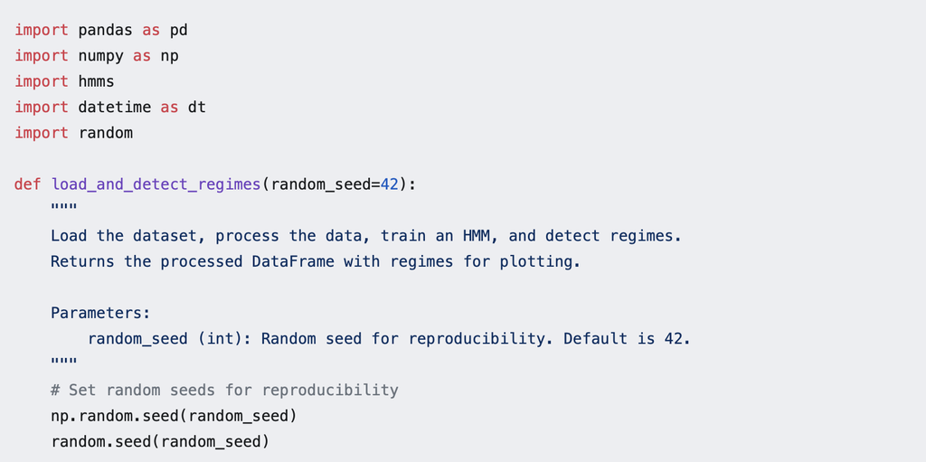

This code block is used to load the entire cleaned CSV database from the specified URL. Then the "date" column is forced as the index of the dataset after converting it to the correct datetime format. Using the datetime object is useful for time series calculations.

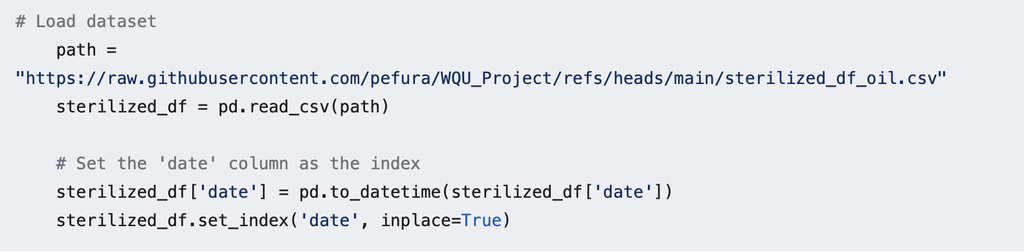

### **4.2.3. Feature's extraction and emission sequence creation**

This section extracts the “WTISPLC” data corresponding to the spot price of WTI crude oil, calculates the monthly price differences (diff), and then transforms these differences into a binary emission sequence. For this representation, the value 1 indicates a price increase while the value 0 represents a price decrease. This simplifies the training for the HMM by focusing on directional changes.

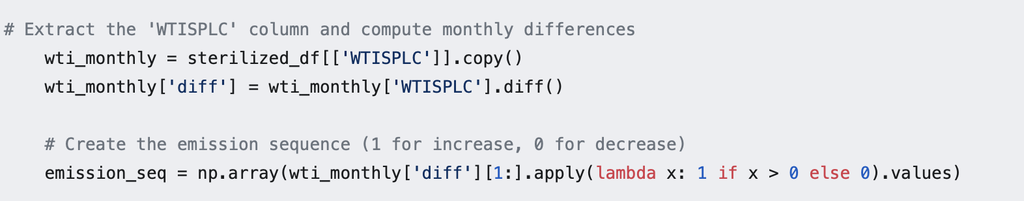

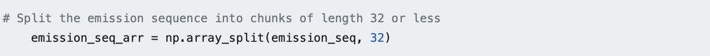

### **4.2.4. HMM initialization, training, and state Prediction**

We initialized an HMM with 3 hidden states representing the different crude oil price regimes (bullish, bearish, stagnant) and 2 possible symbols (increase or decrease in prices). The HMM model is trained by the baum_welch function using the Baum-Welch algorithm. This algorithm is also known as the expectation-maximization (EM) algorithm. It iteratively adjusts the model parameters to maximize the probability of the observed emission sequence. The model parameters are then printed to allow the model components to be appreciated, in particular the transition probabilities between states and the emission probabilities within each state.

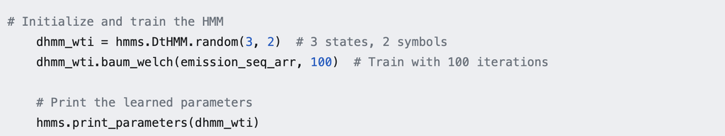

The Viterbi algorithm is then applied to select the most probable hidden state sequence given the observed emission sequence. This is performed here by the "viterbi" function. This algorithm works by computing the hidden state path that maximizes the emission probability of the observed data. The log-likelihood of the most probable sequence (log_ptrob) and the predicted state sequence for the time series (state_seq) are obtained at the end of the Viterbi algorithm recursivity.

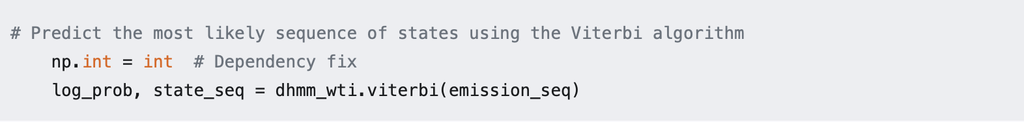

### **4.2.5. Regime mapping and function output**

The last section of the function that encodes the HMM adds the regime prediction to the crude oil price dataframe (wti_monthly). A remapping based on the average price differences in each regime is applied to the regimes to obtain more meaningful labels. The first row of the final result that contained a missing value due to the calculation of monthly price differences is removed. The final result of the function is a processed dataframe ready for further analysis or for visualization of the different regimes.

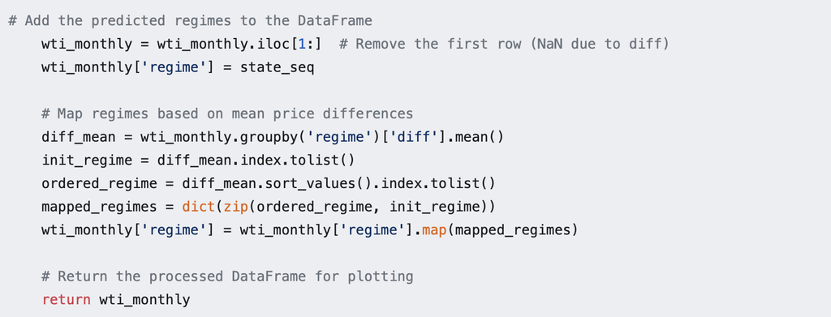

The results are displayed by calling the function and indicating the chosen random seed.

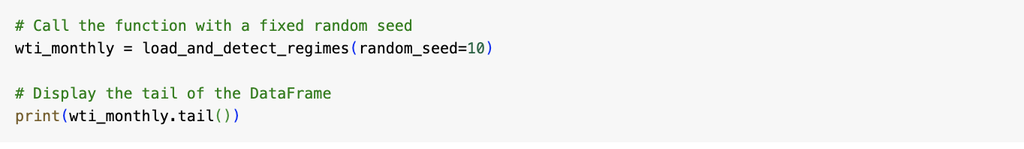

Here are the results obtained with a random_state of 10.

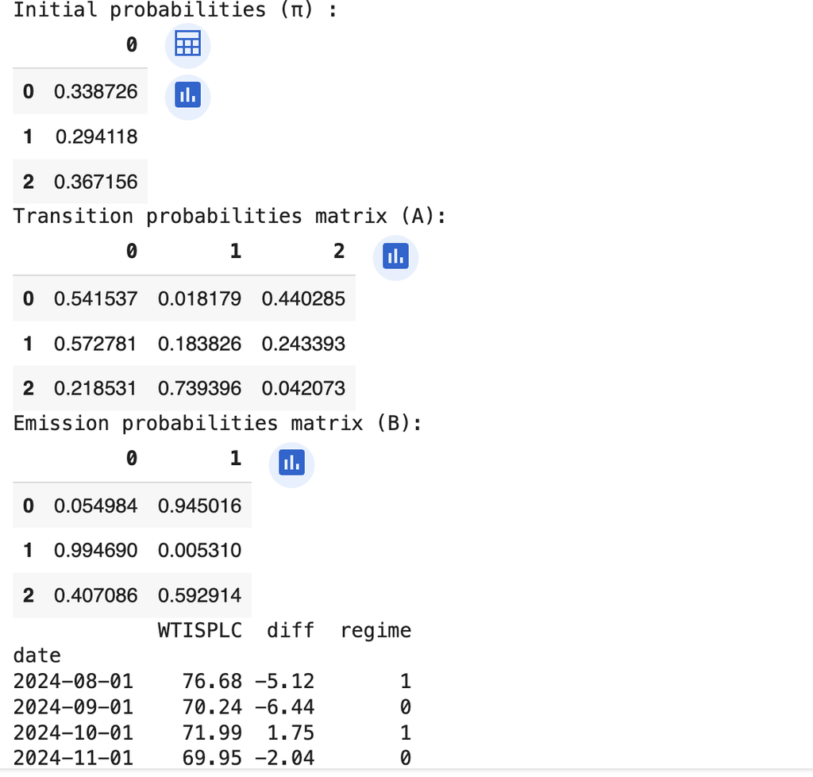

### **4.2.6. Visualization of regimes**

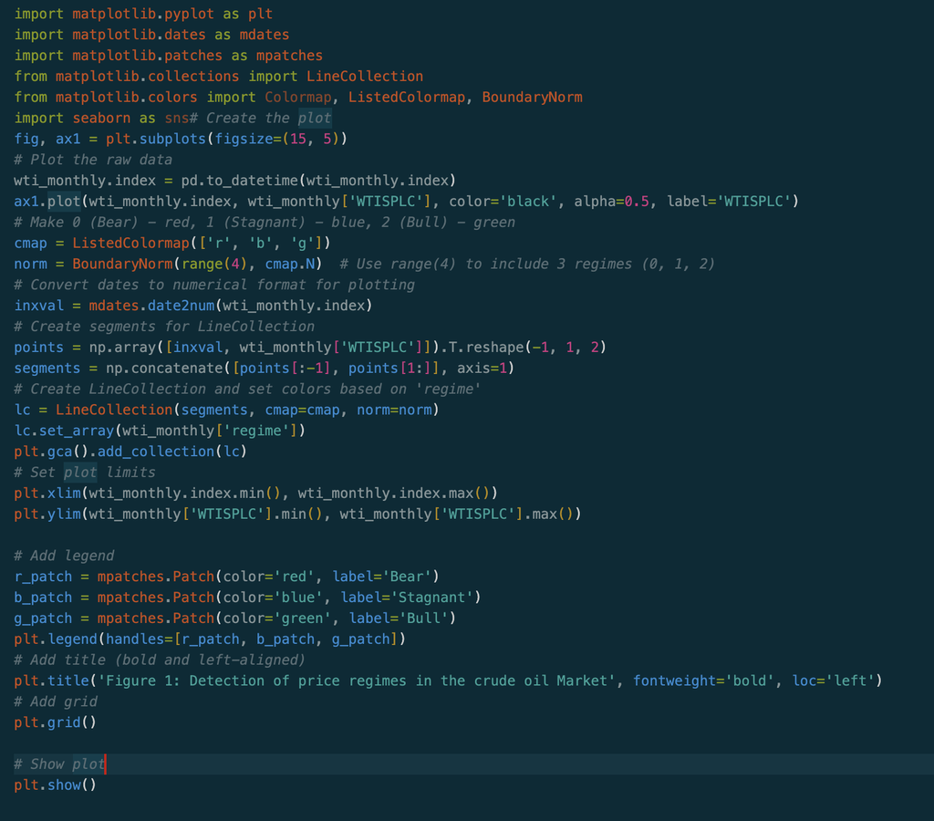

### **4.3. Training and validating Bayesian networks for financial regime prediction**

### **4.3.1. Introduction to Bayesian Network Learning for financial time series**

Bayesian Networks (BNs) are powerful probabilistic graphical models that represent dependencies between a set of variables. BNs are used in financial time series to model relationships between different financial indicators in order to predict future market behavior. To train a BN, we need two steps:

- Structure learning with identification of the network's graphical structure
- Parameter learning with estimation of conditional probability distributions.

In this section we will explain a relevant training approach of BN using the p library.

### **4.3.2. Core Functionalities: Set seeds and data preparation**

The initial part of the code imports the necessary libraries and defines the set_seeds function for reproducibility. The pgmpy modules are used for training and BN estimation.

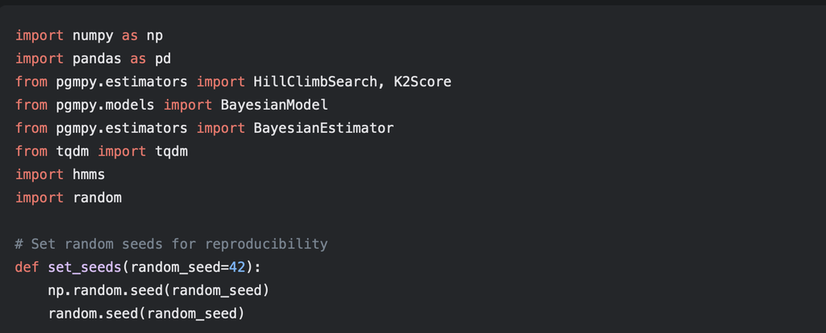

### **4.3.3. Data splitting**

This function splits the dataset into three datasets: training, validation, and test based on the chosen ratios. The training data is used to learn the structure and parameters of the Bayesian network. The test data is used to verify the correct functioning of the model.

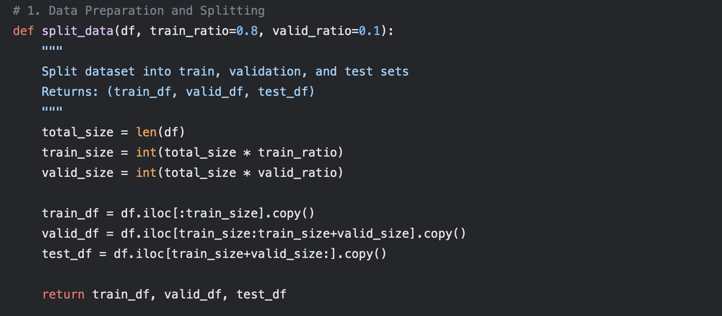

### **4.3.4. Time series discretization**

The application of Bayesian networks often requires the discretization of continuous time series data. This function uses Hidden Markov Models (HMMs) to convert the continuous time series into discrete states. The algorithms used for HMM are described above.

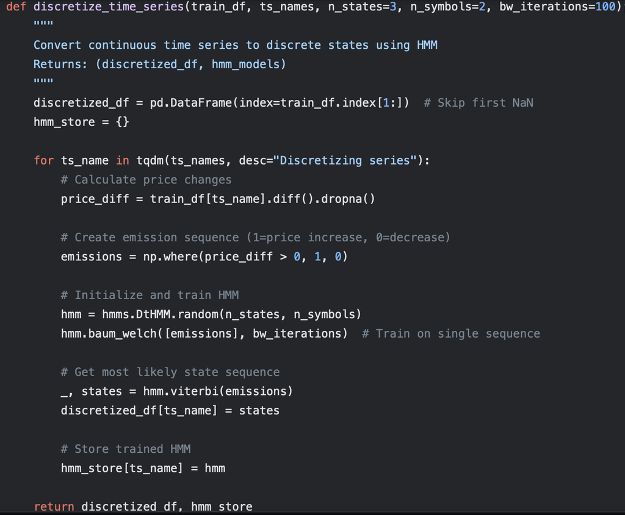

### **4.3.5. Bayesian Network structure learning**

We now have the discretized data and can start training the Bayesian network structure. We use the learn_bayesian_network function which will apply a Hill Climb search algorithm with the K2 score to determine the most likely network structure. This heuristic algorithm will find the maximum value of the likelihood function.

First, a basic Bayesian model is initialized with the provided list of time series and initial nodes (initial_edges). The initial edges can be used to provide domain knowledge. The estimator and scorer are then configured as variables. Finally, the estimator performs function training. Parameters are then learned to better improve predictions. The parameters are learned as follows:

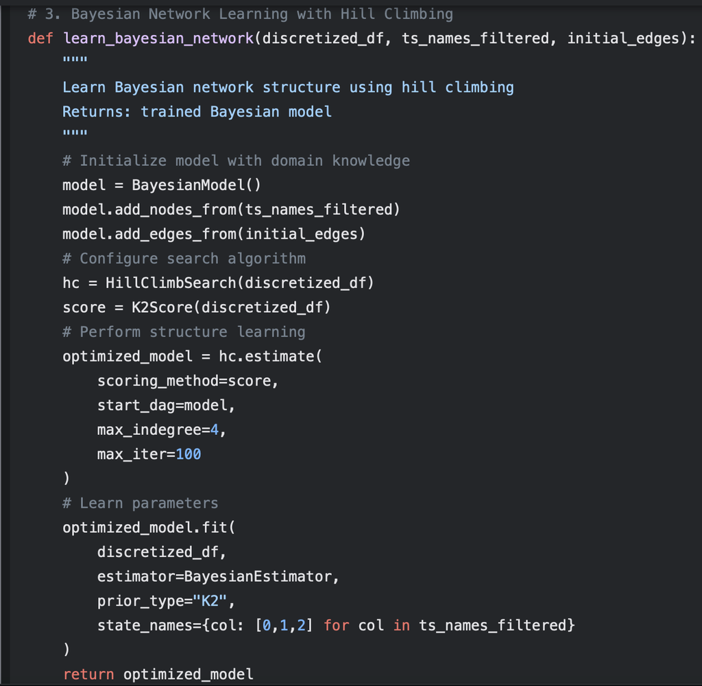

### **4.3.6. Cross-validation and parameter testing**

Implementing a comprehensive cross-validation strategy with backward chaining and other parameter testing techniques is a challenge in Bayesian networks. It requires careful adaptation to the nature of financial time series data.

The code applied for verification uses VariableElimination to test whether the model correctly predicts values, based on information already available. Model validation involves comparing predictions with actual values. The goal is to create a robust model by combining network structure learning, parameter estimation, and cross-validation.

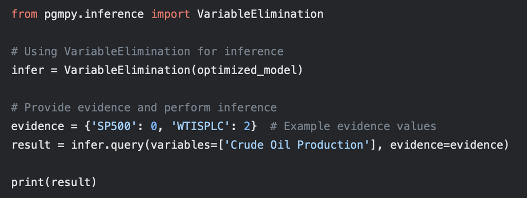

### **4.3.7. Graphing BNs**

The netywork can be ploted using nteworkx pavckage.

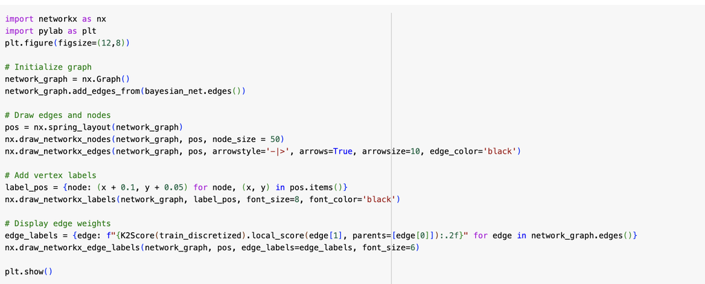

## **Step 6: Regime detection in full dataset**

### **6.1. Time series transformation**

In order to build Hidden Markov Models for detecting regimes in time-series data, we need to transform the time-series data into output emissions. Given the monthly crude oil price data, we could extract the price difference between consecutive months information and discretize it into two possibilities; 1 represents the positive price difference (increasing) from the previous month, and 0 otherwise. The following steps will be performed to transform the time-series data into the emission sequence:

Step 1: Calculate the price difference from the previous month for each data point at time t price_difft =pricet-pricet-1 , for t=1, ..., T

Make sure to exclude the first observation since the price difference value only can be calculated from the second observation onwards. The size of the transformed time series should be equal to T-1.

Step 2: Discretize the price difference into the desired output emissions, where 1 indicates an increase in the price from the previous month, and 0 otherwise. If price_difft >0, then emission_sequencet = 1 , else emission_sequencet = 0

## **Step 7: Identification of the latent meaning behind each hidden state** (Vanluyten et al.; Zhang et al.)

Since there is no information about which hidden states represent the corresponding regime, we need to interpret the meaning of these states and assign them to the correct regimes. In this case, we are using simple statistical measures such as the average of the price difference to summarize the state characteristics. The bear regime indicates the expected price difference tends to decrease (negative value), the bull regime indicates the expected price difference tends to increase (positive value), and the stagnant regime has the expected price difference close to zero. Using these properties, we can assign each state to the correct regime. The following steps are performed to recognize and analyze the meaning of the hidden states:

Step 1: assign the most-likely state sequences generated using the Viterbi algorithm as the state series to the transformed time series.

Step 2: calculate the average of the price_differencefor each hidden state.

Step 3: sort the step 2 result

Step 4: infer and assign the hidden state to the corresponding regime label:

- Bear regime: The state with the lowest average of price_difference(most likely in negative values).
- Stagnant regime: The state with the average of price_differenceclose to zero (not the lowest nor the largest).
- Bull regime: The state with the largest average o f price_difference(most likely in positive values).

## **Step 8: Reading corresponding paper section for Hill Climb**

- Section read.

## **Step 9: Implementation of the minimal working example of a Hill Climb search and identification of the latent meaning behind each hidden state**

### **9.1. Implementation of the minimal working example of a Hill Climb search**

```python
df.columns
```

```python
# Set random seeds for reproducibility
def set_seeds(random_seed=42):
    np.random.seed(random_seed)
    random.seed(random_seed)

# 1. Data Preparation and Splitting
def split_data(df, train_ratio=0.8, valid_ratio=0.1):
    """
    Split dataset into train, validation, and test sets
    Returns: (train_df, valid_df, test_df)
    """
    total_size = len(df)
    train_size = int(total_size * train_ratio)
    valid_size = int(total_size * valid_ratio)

    train_df = df.iloc[:train_size].copy()
    valid_df = df.iloc[train_size:train_size+valid_size].copy()
    test_df = df.iloc[train_size+valid_size:].copy()

    return train_df, valid_df, test_df

# 2. Discretization Function
def discretize_time_series(train_df, ts_names, n_states=3, n_symbols=2, bw_iterations=100):
    """
    Convert continuous time series to discrete states using HMM
    Returns: (discretized_df, hmm_models)
    """
    discretized_df = pd.DataFrame(index=train_df.index[1:])  # Skip first NaN
    hmm_store = {}
    state_stats = {}  # Store statistics for each state in each timeseries

    for ts_name in tqdm(ts_names, desc="Discretizing series"):
        # Calculate price changes
        price_diff = train_df[ts_name].diff().dropna()

        # Create emission sequence (1=price increase, 0=decrease)
        emissions = np.where(price_diff > 0, 1, 0)

        # Initialize and train HMM
        hmm = hmms.DtHMM.random(n_states, n_symbols)
        hmm.baum_welch([emissions], bw_iterations)  # Train on single sequence

        # Get most likely state sequence
        _, states = hmm.viterbi(emissions)
        discretized_df[ts_name] = states

        # Store trained HMM
        hmm_store[ts_name] = hmm

        # --- ADDED SECTION: GATHER STATISTICS ABOUT EACH STATE ---
        state_data = {}
        for state in range(n_states):
            # Find times where the timeseries is in this state
            state_indices = discretized_df[ts_name][discretized_df[ts_name] == state].index

            # Get the corresponding original price changes
            state_price_changes = price_diff[state_indices]

            # Calculate statistics
            state_data[state] = {
                'mean_price_change': state_price_changes.mean(),
                'std_price_change': state_price_changes.std(),
                'num_occurrences': len(state_price_changes)
                #'transition_probs': hmm.transmat_[state]  # Transition probs *from* this state (not easily interpretable without knowing sequence of events)
            }

        state_stats[ts_name] = state_data
        # --- END ADDED SECTION ---

    return discretized_df, hmm_store, state_stats #Return new stat information

# 3. Bayesian Network Learning with Hill Climbing
def learn_bayesian_network(discretized_df, ts_names_filtered, initial_edges):
    """
    Learn Bayesian network structure using hill climbing
    Returns: trained Bayesian model
    """
    # Initialize model with domain knowledge
    model = BayesianModel()
    model.add_nodes_from(ts_names_filtered)
    model.add_edges_from(initial_edges)

    # Configure search algorithm
    hc = HillClimbSearch(discretized_df)
    score = K2Score(discretized_df)

    # Perform structure learning
    optimized_model = hc.estimate(
        scoring_method=score,
        start_dag=model,
        max_indegree=4,
        max_iter=100
    )

    # Learn parameters
    optimized_model.fit(
        discretized_df,
        estimator=BayesianEstimator,
        prior_type="K2",
        state_names={col: [0,1,2] for col in ts_names_filtered}
    )

    return optimized_model

# ANALYZE STATISTICAL SIGNIFICANCE
def analyze_state_stats(state_stats):
        for series_name, stats in state_stats.items():
            print(f"Analyzing states for: {series_name}")
            for state, data in stats.items():
                print(f"  State {state}:")
                for key, value in data.items():
                    print(f"    {key}: {value}")
            print("-" * 40)
# Main Execution Flow
if __name__ == "__main__":
    set_seeds(42)

    # Load and prepare data
    url = "https://raw.githubusercontent.com/pefura/WQU_Project/main/sterilized_df_oil.csv"
    df = pd.read_csv(url, parse_dates=['date'], index_col='date')
    df =  df.drop(columns=['oil_price_return'])

    # Split data
    train_df, valid_df, test_df = split_data(df)

    # Define time series components
    ts_names = [
        'STEO.PAPR_NONOPEC.M', 'STEO.PAPR_OPEC.M',
        'STEO.PATC_OECD.M', 'STEO.PATC_NON_OECD.M',
        'STEO.COPC_OPEC.M', 'WTISPLC'
    ]

    # Discretization step
    train_discretized, hmm_models, state_stats = discretize_time_series(train_df, ts_names) #Grab the returned value to be analyzed

    #Analyze State Statistics
    analyze_state_stats(state_stats)

    # Define network structure constraints
    initial_connections = [
        ('STEO.PAPR_NONOPEC.M', 'WTISPLC'),
        ('STEO.PAPR_OPEC.M', 'WTISPLC'),
        ('STEO.PATC_OECD.M', 'WTISPLC'),
        ('STEO.PATC_NON_OECD.M', 'WTISPLC'),
        ('STEO.COPC_OPEC.M', 'STEO.PATC_OECD.M'),
    ]

    # Structure learning
    bayesian_net = learn_bayesian_network(
        train_discretized[ts_names],
        ts_names,
        initial_connections
    )

    # Output results
    print("Learned Bayesian Network Structure:")
    print(bayesian_net.edges())
```

[output not shown]

### **9.2. Identification of the latent meaning behind each hidden state**

```python
plt.figure(figsize=(12,8))

# Title of the graph
plt.title("Figure 2: Visualization of learned Bayesian Network structure and edge scores", fontweight='bold', loc='left')

# Initialize graph
network_graph = nx.Graph()
network_graph.add_edges_from(bayesian_net.edges())

# Draw edges and nodes
pos = nx.spring_layout(network_graph)
nx.draw_networkx_nodes(network_graph, pos, node_size = 50)
nx.draw_networkx_edges(network_graph, pos, arrowstyle='-|>', arrows=True, arrowsize=10, edge_color='black')

# Add vertex labels
label_pos = {node: (x + 0.1, y + 0.05) for node, (x, y) in pos.items()}
nx.draw_networkx_labels(network_graph, label_pos, font_size=8, font_color='black')

# Display edge weights
edge_labels = {edge: f"{K2Score(train_discretized).local_score(edge[1], parents=[edge[0]]):.2f}" for edge in network_graph.edges()}
nx.draw_networkx_edge_labels(network_graph, pos, edge_labels=edge_labels, font_size=6)

plt.show()
```

[output not shown]

**Table 2: HMM State Descriptions**

[output not shown]

Insights

## **References**

Bank, European Central. “European Central Bank.” European Central Bank, https://www.ecb.europa.eu/home/html/index.en.html. Accessed 10 Feb. 2025.

Bhattacharya, Chandrachur, and Asok Ray. “Data-Driven Detection and Classification of Regimes in Chaotic Systems Via Hidden Markov Modeling.” ASME Letters in Dynamic Systems and Control, vol. 1, no. 021009, Aug. 2020. Silverchair, https://doi.org/10.1115/1.4047817.

Economic Policy Uncertainty Index. https://www.policyuncertainty.com/. Accessed 10 Feb. 2025.

Eddy, Sean R. “Hidden Markov Models.” Current Opinion in Structural Biology, vol. 6, no. 3, June 1996, pp. 361–65. ScienceDirect, https://doi.org/10.1016/S0959-440X(96)80056-X.

Eddy, Sean R. “What Is a Hidden Markov Model?” Nature Biotechnology, vol. 22, no. 10, Oct. 2004, pp. 1315–16. www.nature.com, https://doi.org/10.1038/nbt1004-1315.

Federal Reserve Economic Data | FRED | St. Louis Fed. https://fred.stlouisfed.org/. Accessed 10 Feb. 2025.

Homepage - U.S. Energy Information Administration (EIA). https://www.eia.gov/index.php. Accessed 10 Feb. 2025.

Rabiner, L., and B. Juang. “An Introduction to Hidden Markov Models.” IEEE ASSP Magazine, vol. 3, no. 1, Jan. 1986, pp. 4–16. IEEE Xplore, https://doi.org/10.1109/MASSP.1986.1165342.

Vanluyten, Bart, et al. “A New Approach for the Identification of Hidden Markov Models.” 2007 46th IEEE Conference on Decision and Control, 2007, pp. 4901–05. IEEE Xplore, https://doi.org/10.1109/CDC.2007.4434912.

Wang, Matthew, et al. “Regime-Switching Factor Investing with Hidden Markov Models.” Journal of Risk and Financial Management, vol. 13, no. 12, 12, Dec. 2020, p. 311. www.mdpi.com, https://doi.org/10.3390/jrfm13120311.

World Bank Open Data | Data. https://data.worldbank.org/. Accessed 10 Feb. 2025. Yahoo Finance - Stock Market Live, Quotes, Business & Finance News. https://finance.yahoo.com/. Accessed 22 Aug. 2024.

Zhang, Deyi, et al. “Bayesian Identification of Hidden Markov Models and Their Use for Condition-Based Monitoring.” IEEE Transactions on Reliability, vol. 65, no. 3, Sept. 2016, pp. 1471–82. IEEE Xplore, https://doi.org/10.1109/TR.2016.2570561.

Zheng, Kai, et al. “Regime Switching Model Estimation: Spectral Clustering Hidden Markov Model.” Annals of Operations Research, vol. 303, no. 1, Aug. 2021, pp. 297–319. Springer Link, https://doi.org/10.1007/s10479-019-03140-2.